# Notes for ITS `dada2` on HPC for AVCA-ElkLD project

Lia Ossanna

2023-01-10

## Background

- Total of 69 samples to process:
  - 62 soil samples
  - 7 blanks (4 DNA extraction blanks, 2 blanks from sequencing, and one “unsigned” file)
- Samples were sequenced at the [UA Microbiome Core](https://peds.arizona.edu/steele/microbiome-core) and demultiplexed using `idemp` (see `Notes_idemp_HPC.html` document for instruction).
- These are annotated notes of the `DADA2` pipeline detailed in [this tutorial](https://benjjneb.github.io/dada2/tutorial.html) (ITS tutorial v1.8) for filtering and trimming sequences, merging pair-ends, and constructing the ASV table and taxonomy tables. Comments about the code are written beneath the corresponding chunk.

## High performance computing (HPC)

- This code was run on the UA HPC Puma server through an interactive RStudio session with 94 cores, and a default 5 gb of RAM per core. See the [guide](https://public.confluence.arizona.edu/display/UAHPC/User+Guide), and access UA HPC servers at https://ood.hpc.arizona.edu/.
- Run entirely on HPC server, but in multiple sessions.
- R objects (`.RData`) generated were saved at intermediate steps because a single file was too large (the server tends to crash when the `.RData` file is >10 GB), and because the script was run in multiple sessions. Steps to save intermediate work are noted and discussed.

## Getting ready

- The steps in this section are identical to 16S analysis.

### Load required packages

```r
library(dada2)
library(tidyverse)
```

- Used `dada` version `1.16.0`.

### Set working directory

```r
# Set working directory
setwd("/groups/egornish/lossanna/AVCA-ElkLD_ITS/raw_data/ITS_demultiplexed/")
```

- All the demultiplexed FASTQ files were transferred onto my HPC account using FileZilla Pro.

### Define working folder path

```r
# Define working folder path
path <- "/groups/egornish/lossanna/AVCA-ElkLD_ITS/raw_data/ITS_demultiplexed/"
```

### List files in working folder

```r
# List the files in folder
list.files(path)
```

```
##   [1] "cutadapt"
##   [2] "filtN"
##   [3] "ITS_ASV_rep.txt"
##   [4] "ITS_asv_table.txt"
##   [5] "ITS_dada2_HPC_small.RData"
##   [6] "ITS_dada2_HPC1.RData"
##   [7] "ITS_dada2_HPC2.RData"
##   [8] "ITS_dada2_HPC3.RData"
##   [9] "ITS_sequence_pipeline_stats.txt"
##  [10] "ITS_taxa_table.txt"
##  [11] "Undetermined_S0_L001_I1_001.fastq.gz.decode"
##  [12] "Undetermined_S0_L001_I1_001.fastq.gz.decode.stat"
##  [13] "Undetermined_S0_L001_R1_001.fastq.gz_avca-elkld_01_c21.fastq.gz"
##  [14] "Undetermined_S0_L001_R1_001.fastq.gz_avca-elkld_02_c21.fastq.gz"
##  [15] "Undetermined_S0_L001_R1_001.fastq.gz_avca-elkld_03_c21.fastq.gz"
```

[output cut: 135 more lines]

### Create lists of forward and reverse reads

```r
# Read the names of R1 and R2 files
fnFs <- sort(list.files(path, pattern = "R1.*", full.names = TRUE))
fnRs <- sort(list.files(path, pattern = "R2.*", full.names = TRUE))
fnFs[1:3]
```

```
## [1] "C:/Users/liaos/OneDrive - University of Arizona/grad school/Gornish lab/02_AVCA Elkhorn-Las Delicias/AVCA_ElkLD/amplicon-sequencing/FASTQ_ITS_raw/ITS_demultiplexed/Undetermined_S0_L001_R1_001.fastq.gz_avca-elkld_01_c21.fastq.gz"
## [2] "C:/Users/liaos/OneDrive - University of Arizona/grad school/Gornish lab/02_AVCA Elkhorn-Las Delicias/AVCA_ElkLD/amplicon-sequencing/FASTQ_ITS_raw/ITS_demultiplexed/Undetermined_S0_L001_R1_001.fastq.gz_avca-elkld_02_c21.fastq.gz"
## [3] "C:/Users/liaos/OneDrive - University of Arizona/grad school/Gornish lab/02_AVCA Elkhorn-Las Delicias/AVCA_ElkLD/amplicon-sequencing/FASTQ_ITS_raw/ITS_demultiplexed/Undetermined_S0_L001_R1_001.fastq.gz_avca-elkld_03_c21.fastq.gz"
```

```r
# Check for matching lengths
length(fnFs)
```

```
## [1] 69
```

```r
length(fnFs) == length(fnRs)
```

```
## [1] TRUE
```

## **Identify primers**

- This section is ITS-specific.

### Assign primer sequences

```r
# Assign primer sequences
FWD <- "CTTGGTCATTTAGAGGAAGTAA"  # forward primer sequence
REV <- "GCTGCGTTCTTCATCGATGC"  # reverse primer sequence
```

- These are the primer sequences that UA Microbiome Core uses. They are the universal forward primer ITS1 and reverse primer ITS2.

### Verify presence and orientation of primers

```r
# Verify presence and orientation of primers
allOrients <- function(primer) {
  # Create all orientations of the input sequence
  require(Biostrings)
  dna <- DNAString(primer)  # The Biostrings works w/ DNAString objects rather than character vectors
  orients <- c(Forward = dna, Complement = complement(dna), Reverse = reverse(dna),
               RevComp = reverseComplement(dna))
  return(sapply(orients, toString))  # Convert back to character vector
}

FWD.orients <- allOrients(FWD)
REV.orients <- allOrients(REV)
```

```r
FWD.orients
```

```
##                  Forward               Complement                  Reverse
## "CTTGGTCATTTAGAGGAAGTAA" "GAACCAGTAAATCTCCTTCATT" "AATGAAGGAGATTTACTGGTTC"
##                  RevComp
## "TTACTTCCTCTAAATGACCAAG"
```

```r
REV.orients
```

```
##                Forward             Complement                Reverse
## "GCTGCGTTCTTCATCGATGC" "CGACGCAAGAAGTAGCTACG" "CGTAGCTACTTCTTGCGTCG"
##                RevComp
## "GCATCGATGAAGAACGCAGC"
```

- Verify that the forward, complement, reverse, and reverse complement of the primers is present.

### Pre-filter to remove Ns

```r
# Prefilter to remove sequences with Ns and put N-filtered files in filtN subdirectory
fnFs.filtN <- file.path(path, "filtN", basename(fnFs))
fnRs.filtN <- file.path(path, "filtN", basename(fnRs))
filterAndTrim(fnFs, fnFs.filtN, fnRs, fnRs.filtN, maxN = 0, multithread = TRUE)
```

- Takes about 7 minutes to run on HPC with 94 cores and 5 gb/core.
- Removes sequences that contain ambiguous bases (Ns).
- Creates new copies of `.fastq.gz` files and saves them in a subdirectory named `filtN`.

### Count the presence of primers

```r
primerHits <- function(primer, fn) {
  # Counts number of reads in which the primer is found
  nhits <- vcountPattern(primer, sread(readFastq(fn)), fixed = FALSE)
  return(sum(nhits > 0))
}

primerhits1 <- rbind(FWD.ForwardReads = sapply(FWD.orients, primerHits, fn = fnFs.filtN[[1]]),
                     FWD.ReverseReads = sapply(FWD.orients, primerHits, fn = fnRs.filtN[[1]]),
                     REV.ForwardReads = sapply(REV.orients, primerHits, fn = fnFs.filtN[[1]]),
                     REV.ReverseReads = sapply(REV.orients, primerHits, fn = fnRs.filtN[[1]]))

primerhits8 <- rbind(FWD.ForwardReads = sapply(FWD.orients, primerHits, fn = fnFs.filtN[[8]]),
                     FWD.ReverseReads = sapply(FWD.orients, primerHits, fn = fnRs.filtN[[8]]),
                     REV.ForwardReads = sapply(REV.orients, primerHits, fn = fnFs.filtN[[8]]),
                     REV.ReverseReads = sapply(REV.orients, primerHits, fn = fnRs.filtN[[8]]))
```

```r
primerhits1
```

```
##                  Forward Complement Reverse RevComp
## FWD.ForwardReads       0          0       0       0
## FWD.ReverseReads       0          0       0       6
## REV.ForwardReads       0          0       0      44
## REV.ReverseReads      19          0       0       0
```

```r
primerhits8
```

```
##                  Forward Complement Reverse RevComp
## FWD.ForwardReads       0          0       0       0
## FWD.ReverseReads       0          0       0      14
## REV.ForwardReads       0          0       0     172
## REV.ReverseReads      17          0       0       0
```

- Takes about 0.5-1 minute to make each table.

## **Remove primers using `cutadapt`**

- This section is ITS-specific.

### Installing `cutadapt` on HPC

`cutadapt` is a separate program that runs through `python`, so you must install `python` on your UA HPC account. I tried to create a virtual environment with `python 3.8`, the default version on the HPC server, but would get the following message when I tried to access `cutadapt` through `R`: `/home/u18/lossanna/mypyenv/bin/python3: error while loading shared libraries: libpython3.8.so.1.0: cannot open shared object file: No such file or directory`. However, creating a virtual environment using `python 3.6` and installing `cutadapt` was successful. I don’t know why `python 3.8` didn’t work and `python 3.6` did, but I could not figure out that error message.

### Assign path

```r
cutadapt <- "/home/u18/lossanna/mypyenv36/bin/cutadapt"
system2(cutadapt, args = "--version")
```

### Run `cutadapt`

```r
path.cut <- file.path(path, "cutadapt")
if(!dir.exists(path.cut)) dir.create(path.cut)
fnFs.cut <- file.path(path.cut, basename(fnFs))
fnRs.cut <- file.path(path.cut, basename(fnRs))

FWD.RC <- dada2:::rc(FWD)
REV.RC <- dada2:::rc(REV)
# Trim FWD and the reverse-complement of REV off of R1 (forward reads)
R1.flags <- paste("-g", FWD, "-a", REV.RC)
# Trim REV and the reverse-complement of FWD off of R2 (reverse reads)
R2.flags <- paste("-G", REV, "-A", FWD.RC)
# Run Cutadapt (this takes a while)
for(i in seq_along(fnFs)) {
  system2(cutadapt, args = c(R1.flags, R2.flags, "-n", 2, # -n 2 required to remove FWD and REV from reads
                             "-o", fnFs.cut[i], "-p", fnRs.cut[i], # output files
                             fnFs.filtN[i], fnRs.filtN[i])) # input files
}
```

- The last line (`for` loop) took about 19 minutes to run on HPC with 94 cores.

### Check for presence of primers

```r
primercut1 <- rbind(FWD.ForwardReads = sapply(FWD.orients, primerHits, fn = fnFs.cut[[1]]),
                   FWD.ReverseReads = sapply(FWD.orients, primerHits, fn = fnRs.cut[[1]]),
                   REV.ForwardReads = sapply(REV.orients, primerHits, fn = fnFs.cut[[1]]),
                   REV.ReverseReads = sapply(REV.orients, primerHits, fn = fnRs.cut[[1]]))

primercut8 <- rbind(FWD.ForwardReads = sapply(FWD.orients, primerHits, fn = fnFs.cut[[8]]),
                    FWD.ReverseReads = sapply(FWD.orients, primerHits, fn = fnRs.cut[[8]]),
                    REV.ForwardReads = sapply(REV.orients, primerHits, fn = fnFs.cut[[8]]),
                    REV.ReverseReads = sapply(REV.orients, primerHits, fn = fnRs.cut[[8]]))
```

```r
primercut1 # Success! Primers are no longer detected in the cutadapted reads.
```

```
##                  Forward Complement Reverse RevComp
## FWD.ForwardReads       0          0       0       0
## FWD.ReverseReads       0          0       0       0
## REV.ForwardReads       0          0       0       0
## REV.ReverseReads       0          0       0       0
```

```r
primercut8
```

```
##                  Forward Complement Reverse RevComp
## FWD.ForwardReads       0          0       0       0
## FWD.ReverseReads       0          0       0       0
## REV.ForwardReads       0          0       0       0
## REV.ReverseReads       0          0       0       0
```

- It takes 0.5-1 minute to run each line and build the table.

### Save intermediate `.RData`

```r
save.image("ITS_dada2_HPC1.RData")
```

## **Check `cutadapt` was successful and get sample names**

- This section is similar to 16S analysis, but we are using `cutFs` and `cutRs` rather than `fnFs` and `fnRs`, because there were extra steps to remove Ns and primers.

### Ensure matched files are present

```r
# Read the names of R1 and R2 files
cutFs <- sort(list.files(path.cut, pattern = "R1.*", full.names = TRUE))
cutRs <- sort(list.files(path.cut, pattern = "R2.*", full.names = TRUE))
```

```r
# Check for matching lengths
length(cutFs)
```

```
## [1] 69
```

```r
length(cutFs) == length(cutFs) # TRUE
```

```
## [1] TRUE
```

- There are `69` samples, as expected, and a matched forward and reverse file for each sample.

### Extract sample names

```r
sample.names <- gsub("Undetermined_S0_L001_R1_001.fastq.gz_", "", basename(cutFs))
sample.names <- gsub(".fastq.gz", "", sample.names)
sample.names[1:3]
```

```
## [1] "avca-elkld_01_c21" "avca-elkld_02_c21" "avca-elkld_03_c21"
```

- The file names in `cutFs` are in the format `/groups/egornish/lossanna/AVCA-ElkLD_ITS/raw_data/ITS_demultiplexed/cutadapt/Undetermined_S0_L001_R1_001.fastq.gz_xxx.fastq.gz`, where `xxx` is the sample name we want to extract to make the `sample.names` list.

## Inspect read quality profiles

- This is identical to 16S analysis.

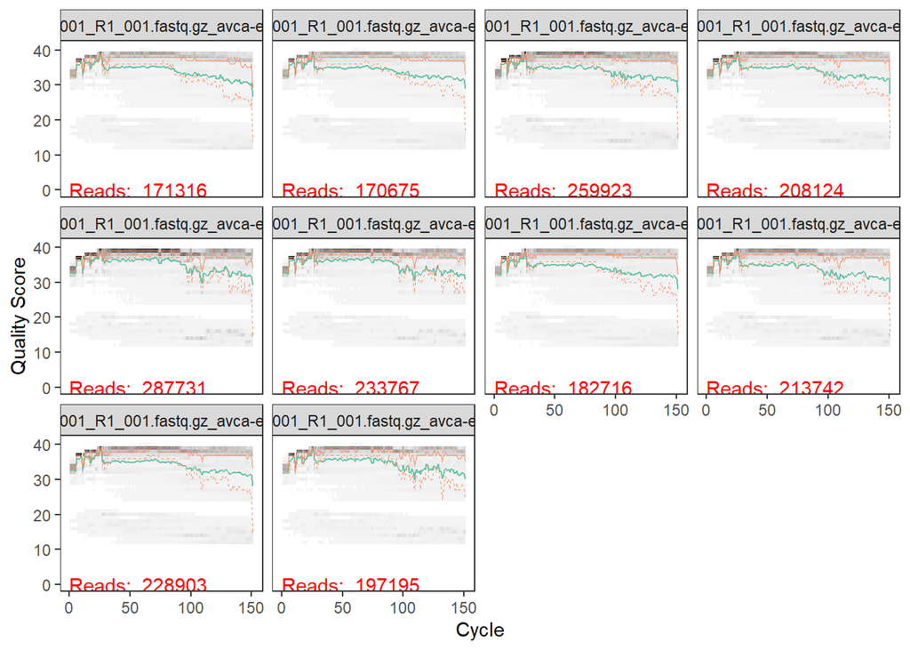

```r
# Inspect quality of sequences in files
plotQualityProfile(fnFs[1:10]) # forward
```

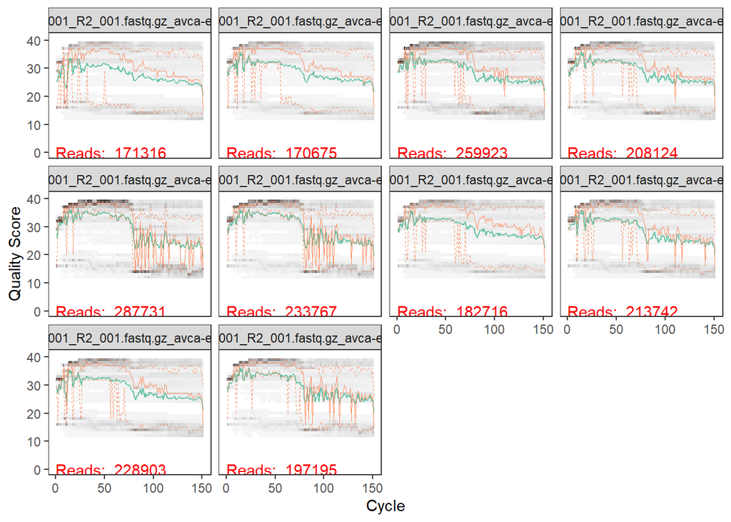

```r
plotQualityProfile(fnRs[1:10]) # reverse
```

- Again, the reverse reads look to be pretty bad quality but I am just going with it.

## **Filter and trim**

- The trimming parameters are slightly different for ITS data.

### Create new fastq files for trimming and filtering

```r
# Place filtered files in filtered/ subdirectory
filtFs <- file.path(path, "filtered", paste0(sample.names, "_F_filt.fastq.gz"))
filtRs <- file.path(path, "filtered", paste0(sample.names, "_R_filt.fastq.gz"))
```

```r
filtFs[1:3]
```

[output not shown]

- This creates new copies of `.fastq.gz` files and saves them in a subdirectory named `filtered`.
  - We now have 4 file versions for each sample:
    1. A version that has been demultiplexed and nothing else, located in the `ITS_demultiplexed/` folder.
    2. A version that has been demultiplexed, and sequences with Ns have been removed, located in the `ITS_demultiplexed/filtNs/` subdirectory.
    3. A version that has been demultiplexed, sequences with Ns removed, and primers removed, located in the `ITS_demultiplexed/cutadapt/` subdirectory.
    4. A version that has been demultiplexed, sequences with Ns removed, primers removed, and filtered, located in the `ITS_demultiplexed/cutadapt/filtered/` subdirectory.

### Trim

```r
# Trim forwards and reverses at 140bp based on quality plots; also trim first 10 bp as recommended
out <- filterAndTrim(cutFs, filtFs, cutRs, filtRs, maxN = 0, maxEE = c(2, 2),
                     truncQ = 2, minLen = 50, rm.phix = TRUE, compress = TRUE, multithread = TRUE) # On Windows set multithread=FALSE

out.df <- as.data.frame(out.df)
```

```r
rownames(out.df) <- sample.names
```

- Took about 3 minutes on HPC with 94 cores with 5 gb/core.
- Output included the warning `Some input samples had no reads pass the filter.`, which refers to a DNA extraction blank that had 0 reads.
  - This is not a problem, except in later pipeline steps there will only be `68` samples instead of `69`, so a few objects have to be altered to have matching lengths or number of rows.
- The first four arguments of `filterAndTrim()` specify the input and output files for the forward and reverse reads.
- `maxN = 0` means that no sequences are allowed with unknown nucleotides (N). This is a standard default.
- `maxEE = c(2, 2)` means that reads with more than `2` expected errors will be discarded. Expected errors are based on the quality score. This is a standard default.
- `truncQ = 2` truncates reads at the first instance of a quality score less than `2`. This is a standard default.
- `rm.phix = TRUE` is another standard default. From R Documentation: “If `TRUE`, discard reads that match against the phiX genome, as determined by `isPhiX`”.
- `compress = TRUE` means that the output fastq files are gzipped (`.gz`).
- `multithread` must be set to `FALSE` on Windows because Windows does not support multithreading in this instance, but can be set to `TRUE` when on the HPC server.

### Check how many reads were removed

```r
# Check out.df to see if filtering was too stringent
head(out.df)[ , 1:2]
```

```
##                   reads.in reads.out
## avca-elkld_01_c21   169613     88636
## avca-elkld_02_c21   168226    102591
## avca-elkld_03_c21   256494    159885
## avca-elkld_04_c21   205362    127645
## avca-elkld_05_c21   285029    190714
## avca-elkld_06_c21   231404    162225
```

```r
range(out.df$reads.out)
```

```
## [1]      0 424016
```

```r
# How much of the data was retained in each sample? The % column is added to out
out.df$Retained = out.df$reads.out / out.df$reads.in * 100
head(out.df)
```

```
##                   reads.in reads.out Retained
## avca-elkld_01_c21   169613     88636 52.25779
## avca-elkld_02_c21   168226    102591 60.98403
## avca-elkld_03_c21   256494    159885 62.33479
## avca-elkld_04_c21   205362    127645 62.15610
## avca-elkld_05_c21   285029    190714 66.91038
## avca-elkld_06_c21   231404    162225 70.10467
```

```r
summary(out.df$Retained)
```

```
##    Min. 1st Qu.  Median    Mean 3rd Qu.    Max.
##    0.00   55.52   61.11   59.31   66.77   75.88
```

- The first samples have 50-70% of the reads retained.

## Learn the error rates

- This section is the same as 16S analysis.

### Model error

```r
# Model and learn error rates in filtered sequences, this takes a while
errF <- learnErrors(filtFs, multithread = TRUE, verbose = TRUE)
errR <- learnErrors(filtRs, multithread = TRUE, verbose = TRUE)
```

- The forward reads took <2 minutes on HPC with 94 cores, and converged after 6 rounds.
- The reverse reads took about 5 minutes, and converged after 7 rounds.
- The output for `errF` and `errR` was: `101045044 total bases in 669471 reads from 5 samples will be used for learning the error rates.`

### Plot error rates

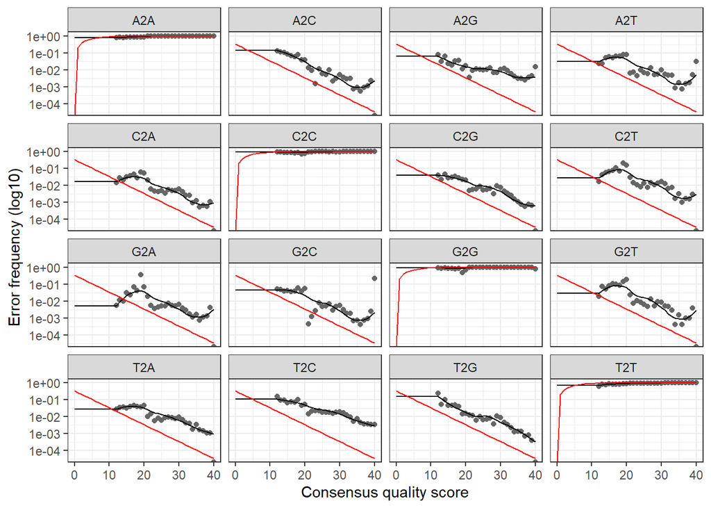

```r
# Plot error rates that are based on nucleotide transition probabilities and quality scores; observed scores (black) should match red lines (expected)
plotErrors(errF, nominalQ = TRUE)
```

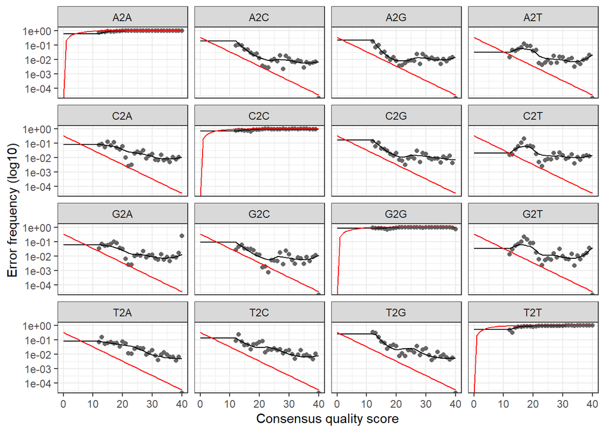

```r
plotErrors(errR, nominalQ = TRUE)
```

- These plots show the expected trends. For the A2A, C2C, G2G, and T2T plots the black lines (observed scores) match the red lines (expected scores) well.

### Save intermediate `.RData`

```r
save.image("ITS_dada2_HPC1.RData")
```

## Sample inference

- This section is the same as 16S analysis.

### Remove replicate sequences

```r
# Find files with 0 reads retained
out.df %>%
  filter(Retained == 0)
```

```
##                   reads.in reads.out Retained
## avca-elkld_blank3        3         0        0
```

```r
filtFs # blank3 is 67
```

[output not shown]

[output cut: 54 more lines]

```r
filtFs2 <- filtFs[-67]
filtRs2 <- filtRs[-67]

sample.names2 <- sample.names[-67]
```

- Because one of the samples (`avca-elkld_blank3`, DNA extraction blank 3) had 0 reads after filtering, no file was created for it, so we need to alter the `filtFs` and `filtRs` objects, which are vectors of all the file names, since no filtered file for `avca-elkld_blank3` exists.
- Similarly, we must also create a new vector of sample names that excludes `avca-elkld_blank3`.

```r
# Reduce computation time by dereplicating identical sequences
derepFs <- derepFastq(filtFs2, verbose = TRUE)
derepRs <- derepFastq(filtRs2, verbose = TRUE)

# Name the derep-class objects by the sample names
names(derepFs) <- sample.names2
names(derepRs) <- sample.names2
```

### Save intermediate `.RData`

```r
save(derepFs, derepRs, file = "ITS_dada2_HPC2.RData") # save as new file because derepFs is 3.9 GB and derepRs is derepRs is 8.6 GB
```

- At this stage, we can no longer save entire workspace image using `save.image()` because it causes the server to crash. Instead, we must save specific objects in multiple files using `save()`.

### Infer true sequence variants

```r
# Sample inference, this takes a while
dadaFs <- dada(derepFs, err = errF, multithread = TRUE)
dadaRs <- dada(derepRs, err = errR, multithread = TRUE)
```

- The first line of code took about 5.5 min to run on HPC with 94 cores and 5 gb/core.
  - Samples 1-67 took about 4 minutes to run.
  - Sample 68 was of all the “unsigned” reads and was `Sample 68 - 424016 reads in 228714 unique sequences.`, and took about 1.5 minutes to run just this sample, which was bigger than the rest (for comparison, Sample 1 was `Sample 1 - 88636 reads in 28024 unique sequences.`).
- The second line of code took about 11 minutes to run.

### Inspect the `dada-class` object

```r
dadaFs[[1]]
```

```
## dada-class: object describing DADA2 denoising results
## 397 sequence variants were inferred from 28024 input unique sequences.
## Key parameters: OMEGA_A = 1e-40, OMEGA_C = 1e-40, BAND_SIZE = 16
```

### Save intermediate `.RData`

```r
save(filtFs2, filtRs2, sample.names2, dadaFs, dadaRs, file = "ITS_dada2_HPC3.RData")
```

## Merge pair-end reads

- This section is the same as 16S analysis.

### Join forward and reverse reads

```r
# Join forward and reverse reads
mergers <- mergePairs(dadaFs, derepFs, dadaRs, derepRs, verbose = TRUE)
```

- It takes <1 second to merge each sample on HPC with 94 cores at 5 gb/core (running entire line took <1 min).
- The output is something like `68990 paired-reads (in 244 unique pairings) successfully merged out of 83616 (in 542 pairings) input.`, and will go through each sample.
- The default is an overlap of 12 bp.

### Inspect merger

```r
# Inspect the merger data.frame from the first sample
head(mergers[[1]])
```

```
##                                                                                                                                                                                                                                                                              sequence
## 1                                                                  GTAGGTGAACCTGCGGAAGGATCATTACCGAGTAGATGGGTTAACAGCCCCCACTCCAAC…
## 2                                                       GTTGGTGAACCAGCGGAGGGATCATTACAGAGTTGCAAAACTCCAAACCATTGTGAACCT…
## 3                                                   GTAGGTGAACCTGCGGAAGGATCATTACATGGCGGAGGAGGTGGGCACCTGGCGACACCG…
## 4 GTAGGTGAACCTGCGGAAGGATCATTAATGAATAAACTTGGTCGAGCTGTTGCTGATCCC…
## 5                                                                              GTAGGTGAACCTGCGGAAGGATCATTACCGAGTACTCGGGGGGCTACTCCCCCGGACTCCCACCCATTGCTTACTTACCCGTTCCTTCGGCGAAGGGCGGCGTCCCCTGGGGCGCTCCGTCGCCGGCCTTTCAAAACCTCGAGCTTAAACGGTGCAGTCTGAGCATTTGCAAGCAAAATATAAAAACTTTCAACAACG
## 6                                                                                              GTAGGTGAACCTGCGGAAGGATCATTACCTAGAGTCAGTGGGCTTTGCCTGCTATCTCTTACCCATGTTTTATGAGCACTTACGTTTCCTCGGTGGGTTCGCCCACCGATTGGACCACTTAAACCCTTTGCAGTTTTGTAATCAGCGTCTGAAAAACTTAATAGTTACAACTTTCAACAACG
##   abundance forward reverse nmatch nmismatch nindel prefer accept
## 1      6203       1       2     92         0      0      1   TRUE
## 2      5048       3       1     81         0      0      2   TRUE
## 3      4468       7       4     77         0      0      1   TRUE
## 4      4118       4       3     27         0      0      1   TRUE
## 5      3645       2       5    104         0      0      1   TRUE
## 6      3048       5       6    120         0      0      1   TRUE
```

### Save intermediate `.RData`

```r
save(filtFs2, filtRs2, sample.names2, dadaFs, dadaRs, mergers,
     file = "ITS_dada2_HPC3.RData")
```

## Construct sequence table

- This section is the same as 16S analysis.

### Make ASV table

```r
seqtab <- makeSequenceTable(mergers)
```

```r
dim(seqtab)
```

```
## [1]   68 7111
```

```r
# Inspect sequence lengths: Most amplicon sequence variants are 233bp
table(nchar(getSequences(seqtab)))
```

```
##
## 115 138 139 140 143 144 145 146 147 149 151 152 153 154 155 156 157 158 159 160
##   1   1   2   5   4   3   1   3   3   3  24  47  56  49  47  34  44  33  25  27
## 161 162 163 164 165 166 167 168 169 170 171 172 173 174 175 176 177 178 179 180
##  49  11  24  24  19  34  21  24  20   9  17  11  23  11  40  15  41  40  47  44
## 181 182 183 184 185 186 187 188 189 190 191 192 193 194 195 196 197 198 199 200
##  50  65  56 103  71  64  90  74  63  79  64  35  60  69  67  87  76  51  49  62
## 201 202 203 204 205 206 207 208 209 210 211 212 213 214 215 216 217 218 219 220
##  51  51  76  76  64  75  66 105  78  93  82  99  77  89  92 118  95  64  63  77
## 221 222 223 224 225 226 227 228 229 230 231 232 233 234 235 236 237 238 239 240
## 101  81  59  75  65  86  86  69  61  88  82  85  73 100  79  78  80 111  63  73
## 241 242 243 244 245 246 247 248 249 250 251 252 253 254 255 256 257 258 259 260
##  72  64  60  34  57  30  51  61  30  33  17  23  32  31  46  33  27  36  56  67
## 261 262 263 264 265 266 267 268 269 270 271 272 273 274 275 276 277 278 279 280
##  18  29  25  16  20  24  18  32  33  20  14  33  23  24  35  33  37  29  23  22
## 281 282 283 284 285 286 287 288 289 290
##  17  21  31  29  60  14  23  40  23  28
```

- The most abundant length is `216` bp, with `118` ASVs of that length.

### Save intermediate `.RData`

```r
save(filtFs2, filtRs2, sample.names2, dadaFs, dadaRs, mergers, seqtab,
     file = "ITS_dada2_HPC3.RData")
```

## Remove chimeras

- This section is the same as 16S analysis.

### Create new ASV table without chimeras

```r
seqtab.nochim <- removeBimeraDenovo(seqtab,
                                    method = "consensus",
                                    multithread = TRUE,
                                    verbose = TRUE)
```

- Takes <1 min to run on HPC with 94 cores and 5 gb/core.
- The output was: “`Identified 192 bimeras out of 7111 input sequences.`”

```r
dim(seqtab.nochim)
```

```
## [1]   68 6919
```

```r
# How much of the dataset is left after chimera identification and removal?
sum(seqtab.nochim) / sum(seqtab) * 100
```

```
## [1] 99.57993
```

### Save intermediate `.RData`

```r
save(filtFs2, filtRs2, sample.names2, dadaFs, dadaRs, mergers, seqtab, seqtab.nochim,
     file = "ITS_dada2_HPC3.RData")
```

## Track reads through pipeline

- This section is the same as 16S analysis.

### Create table to track reads

```r
# Create function
getN <- function(x) sum(getUniques(x))

# Create table
out.df2 <- out.df[-67, ] # remove blank3
track <- cbind(out.df2, sapply(dadaFs, getN), sapply(dadaRs, getN), sapply(mergers, getN), rowSums(seqtab.nochim))

# Rename columns
colnames(track) <- c("input",
                     "filtered",
                     "Retained %",
                     "denoisedF",
                     "denoisedR",
                     "merged",
                     "nonchim")
rownames(track) <- sample.names2

# Total percent of dataset remaining
track$InputRetained <- track$nonchim / track$input * 100
head(track)
```

```
##                    input filtered Retained % denoisedF denoisedR merged nonchim
## avca-elkld_01_c21 169613    88636   52.25779     87700     84265  68990   68914
## avca-elkld_02_c21 168226   102591   60.98403    101408     96467  71274   71265
## avca-elkld_03_c21 256494   159885   62.33479    157919    152682  70682   70681
## avca-elkld_04_c21 205362   127645   62.15610    125913    122168  82013   82012
## avca-elkld_05_c21 285029   190714   66.91038    189196    181292  95486   95486
## avca-elkld_06_c21 231404   162225   70.10467    160796    157438  78849   78844
##                   InputRetained
## avca-elkld_01_c21      40.63014
## avca-elkld_02_c21      42.36265
## avca-elkld_03_c21      27.55659
## avca-elkld_04_c21      39.93533
## avca-elkld_05_c21      33.50045
## avca-elkld_06_c21      34.07201
```

```r
summary(track$InputRetained)
```

```
##    Min. 1st Qu.  Median    Mean 3rd Qu.    Max.
##  0.7936 33.1484 39.7294 36.6059 43.0469 63.8889
```

```r
track$FilteredRetained <- track$nonchim / track$filtered * 100
head(track)
```

```
##                    input filtered Retained % denoisedF denoisedR merged nonchim
## avca-elkld_01_c21 169613    88636   52.25779     87700     84265  68990   68914
## avca-elkld_02_c21 168226   102591   60.98403    101408     96467  71274   71265
## avca-elkld_03_c21 256494   159885   62.33479    157919    152682  70682   70681
## avca-elkld_04_c21 205362   127645   62.15610    125913    122168  82013   82012
## avca-elkld_05_c21 285029   190714   66.91038    189196    181292  95486   95486
## avca-elkld_06_c21 231404   162225   70.10467    160796    157438  78849   78844
##                   InputRetained FilteredRetained
## avca-elkld_01_c21      40.63014         77.74945
## avca-elkld_02_c21      42.36265         69.46516
## avca-elkld_03_c21      27.55659         44.20740
## avca-elkld_04_c21      39.93533         64.25007
## avca-elkld_05_c21      33.50045         50.06764
## avca-elkld_06_c21      34.07201         48.60163
```

```r
summary(track$FilteredRetained)
```

```
##    Min. 1st Qu.  Median    Mean 3rd Qu.    Max.
##    4.02   54.87   64.78   59.79   69.46   89.72
```

- A majority of the total reads are not retained, but a majority of the filtered reads are.
- Samples should have a majority of reads retained, so even if there is a large number of chimeras, they should relatively low in abundance. See [this tutorial FAQ](https://benjjneb.github.io/dada2/faq.html#why-are-so-many-of-my-reads-being-removed-as-chimeras) for more details.

```r
# Track soil samples only
track.soil <- track[1:62, ]
summary(track.soil$InputRetained)
```

```
##    Min. 1st Qu.  Median    Mean 3rd Qu.    Max.
##   15.23   34.14   40.09   38.64   43.14   54.60
```

```r
summary(track.soil$FilteredRetained)
```

```
##    Min. 1st Qu.  Median    Mean 3rd Qu.    Max.
##   25.95   58.50   65.58   62.58   69.46   80.85
```

- Examine soil samples only, not including blanks or the unsigned sample.

### Save intermediate `.RData`

```r
save(filtFs2, filtRs2, sample.names2, dadaFs, dadaRs, mergers, seqtab, seqtab.nochim, track, track.soil,
     file = "ITS_dada2_HPC3.RData")
```

## **Assign taxonomy**

```r
taxa <- assignTaxonomy(seqtab.nochim,
                       "/home/u18/lossanna/sh_general_release_dynamic_all_29.11.2022.fasta",
                       multithread = TRUE,
                       tryRC = T)
```

- Took about 11 minutes with 94 cores and 5 gb/core.
- DOI for UNITE database used: https://dx.doi.org/10.15156/BIO/2483913.
  - Used the `sh_general_release_all_29.11.2022.tgz` download.
- Had to download 7-Zip Installer to unzip file and get `.fasta` file.

## Create ASV rep table

- This section is the same as 16S analysis.

```r
# Create ASV rep table
ASV.rep <- data.frame(rep = colnames(seqtab.nochim))

# Add ASV number column
ASV.rep$ASV <- c(1:ncol(seqtab.nochim))

# Add ASV_ to column
ASV.rep$ASV <- paste("ASV_", ASV.rep$ASV, sep = "")
```

## Add ASV names to other tables

- This section is the same as 16S analysis.

```r
# Change the representative sequence in ASV and taxonomy tables to ASV ID
colnames(seqtab.nochim) <- ASV.rep$ASV
rownames(taxa) <- ASV.rep$ASV
```

## **Clean up taxa table**

- This section is ITS-specific, because the UNITE database is formatted slightly differently.

```r
# Remove "__" from taxa table
taxa <- as.data.frame(taxa)
taxa <- separate(taxa, Kingdom, c("k", "Kingdom"), "__")
taxa <- separate(taxa, Phylum, c("p", "Phylum"), "__")
taxa <- separate(taxa, Class, c("c", "Class"), "__")
taxa <- separate(taxa, Order, c("o", "Order"), "__")
taxa <- separate(taxa, Family, c("f", "Family"), "__")
taxa <- separate(taxa, Genus, c("g", "Genus"), "__")
taxa <- separate(taxa, Species, c("s", "Species"), "__")
drop <- c("k", "p", "c", "o", "f", "g", "s")
taxa <- select(all_of(taxa, -drop))
```

## Save tables as plain text files (`.txt`)

- This section is the same as 16S analysis.

```r
# Save ASV table, taxonomy table and ASV rep
write.table(taxa, "ITS_taxa_table.txt", sep = "\t", quote = FALSE)
write.table(seqtab.nochim, "ITS_asv_table.txt", sep = "\t", quote = FALSE)
write.table(track, "ITS_sequence_pipeline_stats.txt", sep = "\t", quote = FALSE)
write.table(ASV.rep,"ITS_ASV_rep.txt",sep = "\t", quote = FALSE)
```

### Save intermediate `.RData`

```r
save(filtFs2, filtRs2, sample.names2, dadaFs, dadaRs, mergers, seqtab,
     seqtab.nochim, out.df2, track, track.soil, taxa, ASV.rep,
     file = "ITS_dada2_HPC3.RData")

# Remove large objects and save workspace
rm(derepFs, derepRs)
save.image("ITS_dada2_HPC_small.RData")
```

- The only files that are very large and cause the system to crash are the `derepFs` and `derepRs` objects. Remove those, and all the objects can be saved in a single file.